# Cyclistic

Tyler Lonergan

2023-09-08

# Cyclistic

In 2016, Cyclistic launched a successful bike-share offering. Since then, the program has grown to a fleet of 5,824 bicycles that are geotracked and locked into a network of 692 stations across Chicago. The bikes can be unlocked from one station and returned to any other station in the system anytime.

Member riders are those who have purchased an annual pass that grants unlimited access to the Cyclistic bike-share system all year round. Casual members have purchased either a single-way ride or a full day pass, granting unlimited access to the bike-share system for a 24 hour period, starting at the time of sale.

## Three questions will guide the future marketing program:

- How do annual members and casual riders use Cyclistic bikes differently?
- Why would casual riders buy Cyclistic annual memberships?
- How can Cyclistic use digital media to influence casual riders to become members?

## Deliverables

- A clear statement of the business task
- A summary of your analysis
- Supporting visualizations and key findings
- Your top three recommendations based on your analysis
- A description of all data sources used
- Documentation of any cleaning or manipulation of data

### Statement of the business task

Cyclistic wants to understand differences between annual riders and casual riders, so that they can piece together why casual riders would convert to annual memberships. Cyclistic has determined that annual members are significantly more profitable than casual riders, so there is a strong business driver to make those conversions. Lastly, they are wanting to target the casual riders by using digital media and are looking at ways to effectively convert more riders into members.

### Summary of analysis

I’ve analyzed the mean, median, min, and max ride lengths for each customer type: members and casual riders. All values are provided in seconds. I also have shown the average ride time per user type per day of the week.

##### Average ride length by member type:

| Member/Casual | Average_Ride_Length |
| --- | --- |
| casual | 1398.9097 secs |
| member | 748.2286 secs |

##### Median ride length by member type:

| Member/Casual | Median_Ride_Length |
| --- | --- |
| casual | 816 secs |
| member | 540 secs |

##### Longest ride length by member type:

[output not shown]

##### Shortest ride length by member type:

| Member/Casual | Min_Ride_Length |
| --- | --- |
| casual | 1 secs |
| member | 1 secs |

I have also shown the average number of trips taken by each user type on each day of the week. In general, members have more rides per day of the week during the work week, but casual riders spike interest on Saturdays and Sundays.

| member_casual | day | number_of_rides | average_duration |
| --- | --- | --- | --- |
| casual | Monday | 228785 | 1445.0966 secs |
| casual | Tuesday | 214500 | 1249.9971 secs |
| casual | Wednesday | 222937 | 1207.3596 secs |
| casual | Thursday | 251897 | 1247.6005 secs |
| casual | Friday | 272074 | 1304.9763 secs |
| casual | Saturday | 397097 | 1563.8764 secs |
| casual | Sunday | 325701 | 1590.0109 secs |
| member | Monday | 409045 | 723.4910 secs |
| member | Tuesday | 448250 | 709.7391 secs |
| member | Wednesday | 451114 | 712.0667 secs |
| member | Thursday | 455870 | 723.3373 secs |
| member | Friday | 395633 | 735.4299 secs |
| member | Saturday | 373614 | 837.0703 secs |
| member | Sunday | 328133 | 830.2174 secs |

I searched all five of the top visited locations in Chicago and found the majority to surround tourist sites:

| Station_Names | Station_Points_of_Interest |
| --- | --- |
| Streeter Dr & Grand Ave | Chicago Children’s Museum |
| DuSable Lake Shore Dr & North Blvd | Post Office, Federal Building, LaSalle Street Station |
| Michigan Ave & Oak St | Lakefront Park, Oak Street Beach |
| DuSable Lake Shore Dr & Monroe St | Milennium Park, Art Institute of Chicago, Queen’s Landing |
| Wells St & Concord Ln | Lincoln Park, Chicago History Museum |

Corresponding points of interest for Member rider most visited stations

| Station_Names | Station_Points_of_Interest |
| --- | --- |
| Kingsbury St & Kinzie St | Kingsbury Plaza |
| Clark St & Elm St | Clark/Division Red Line Station |
| Wells St & Concord Ln | Lincoln Park, Chicago History Museum |
| University Ave & 57th St | University of Chicago |
| Clinton St & Washington Blvd | Ogilvie Transportation Station |

Corresponding points of interest for Casual rider most visited stations

| Station_Names | Station_Points_of_Interest |
| --- | --- |
| Streeter Dr & Grand Ave | Chicago Children’s Museum |
| DuSable Lake Shore Dr & Monroe St | Milennium Park, Art Institute of Chicago, Queen’s Landing |
| Millennium Park | Millennium Park |
| Michigan Ave & Oak St | Lakefront Park, Oak Street Beach |
| DuSable Lake Shore Dr & North Blvd | Post Office, Federal Building, LaSalle Street Station |

Two of the stations members frequent the most are additional transit lines, and the University of Chicago being on this list suggests that students are already likely to have annual passes. This finding also supports the recommendation to target students for annual passes.

These most visited locations strongly support the idea that annual members are commuting to work, school, and other destinations, and that casual riders are much more likely to be either tourists or residents who only use the bikes on an as-needed basis.

### Supporting visualizations and key findings

This graph supports the first idea in the analysis, showing the spike in casual ridership over the weekend.

[figure not shown]

This set of charts shows the daily average trip lengths by rider type. It is clear across all time periods that casual riders take longer trips than annual members. Annual members also do not fluctuate nearly as much. This supports the hypothesis that annual members are using Cyclistic services for commuting to work or school, as that would be a fixed distance and therefore a very similar ride duration day after day.

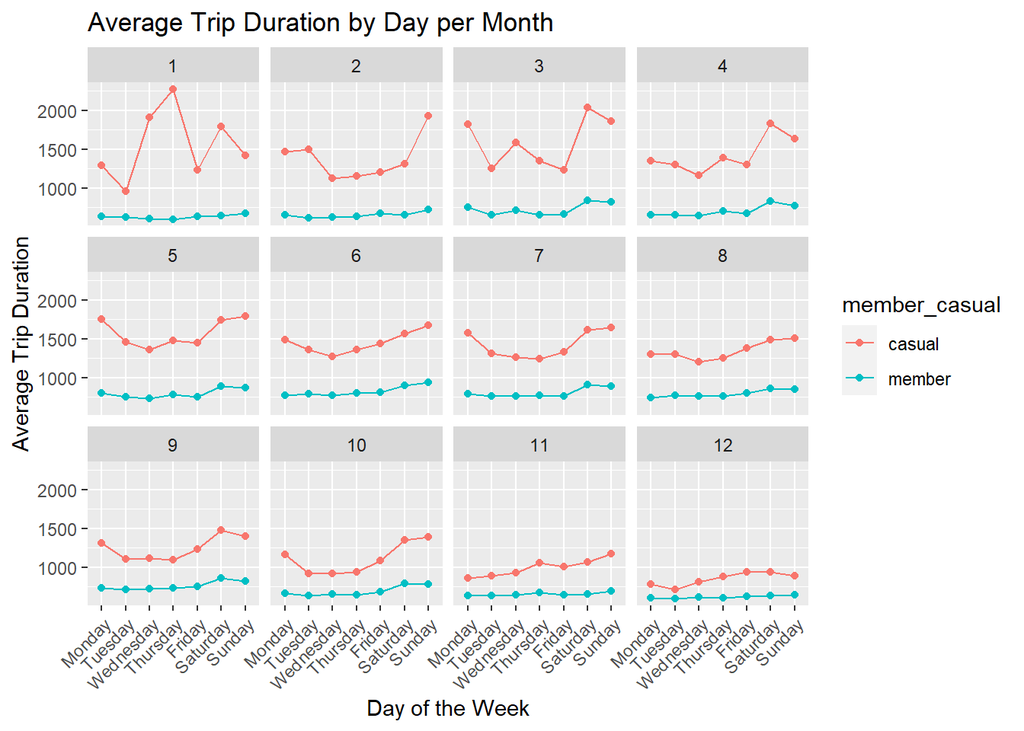

Chicago winters can be harsh, and that is reflected in the following visual, which shows the number of rides taken for days of the week, broken out by month. December, January, and February see sharp drops in ride counts, which start to recover slowly in March and April into May before peaking in the warmer months.

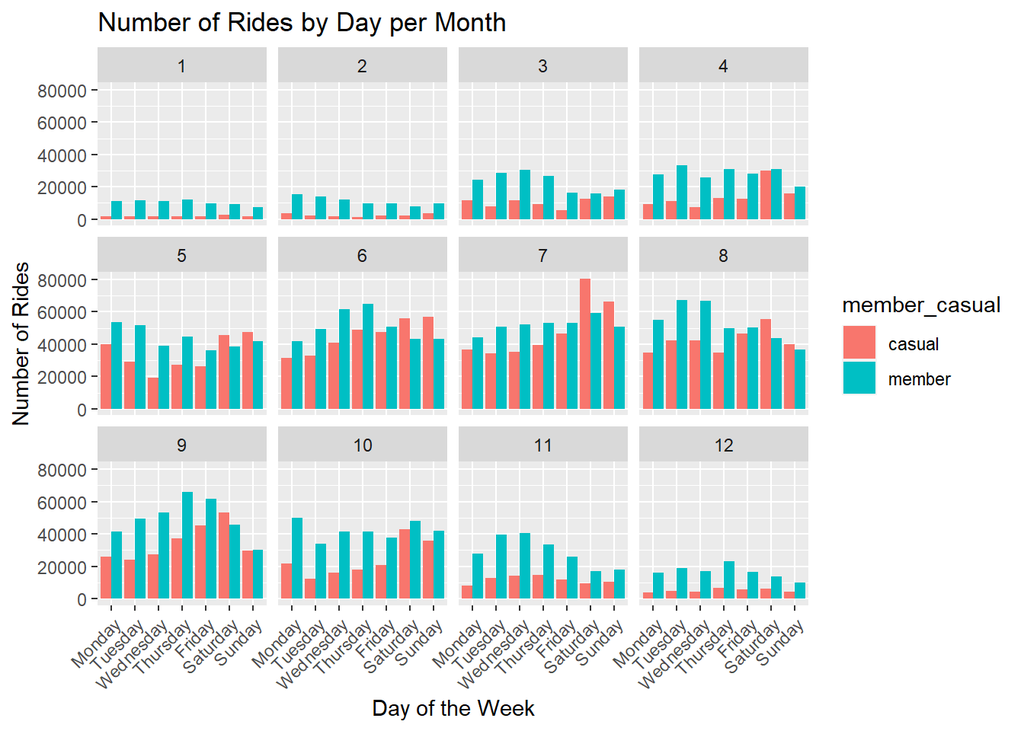

These charts show the stations most likely to be visited by all riders, as well as the top stations for each user type. Based on the tables above, showing the points of interest at the top 5 stations, it’s clear that casual riders are more likely to visit tourist attractions and activities. Member riders are likely to be heading toward places of commerce, transit, or education.

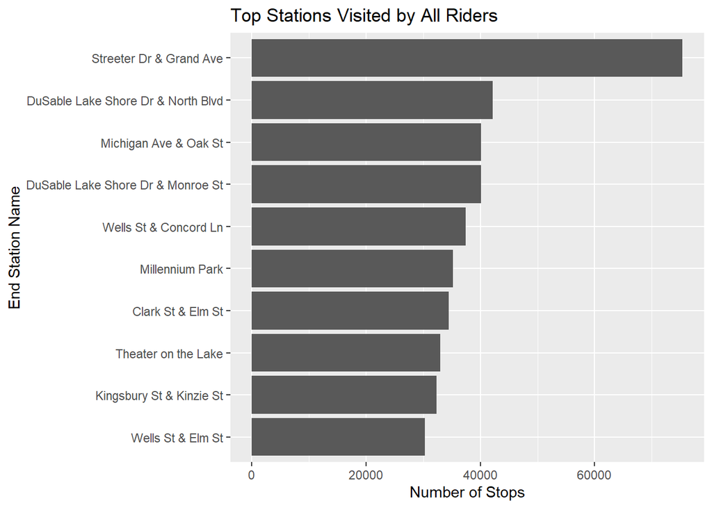

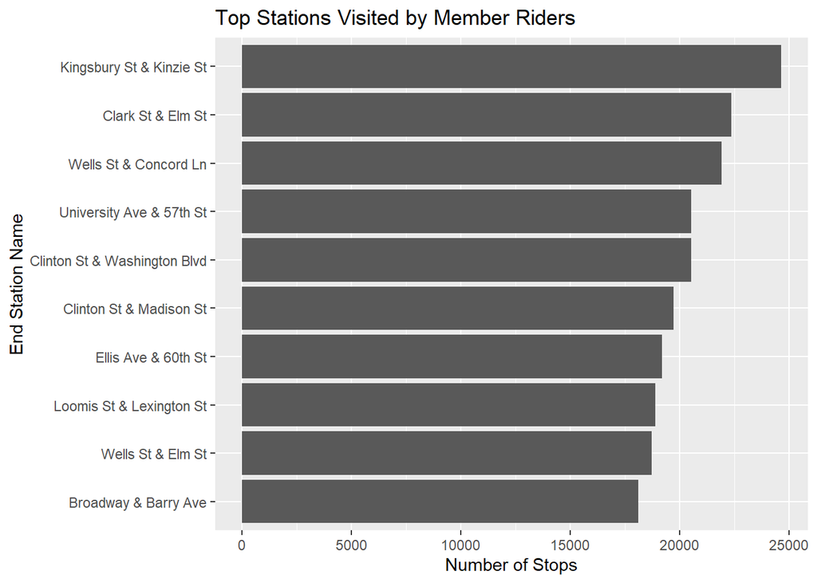

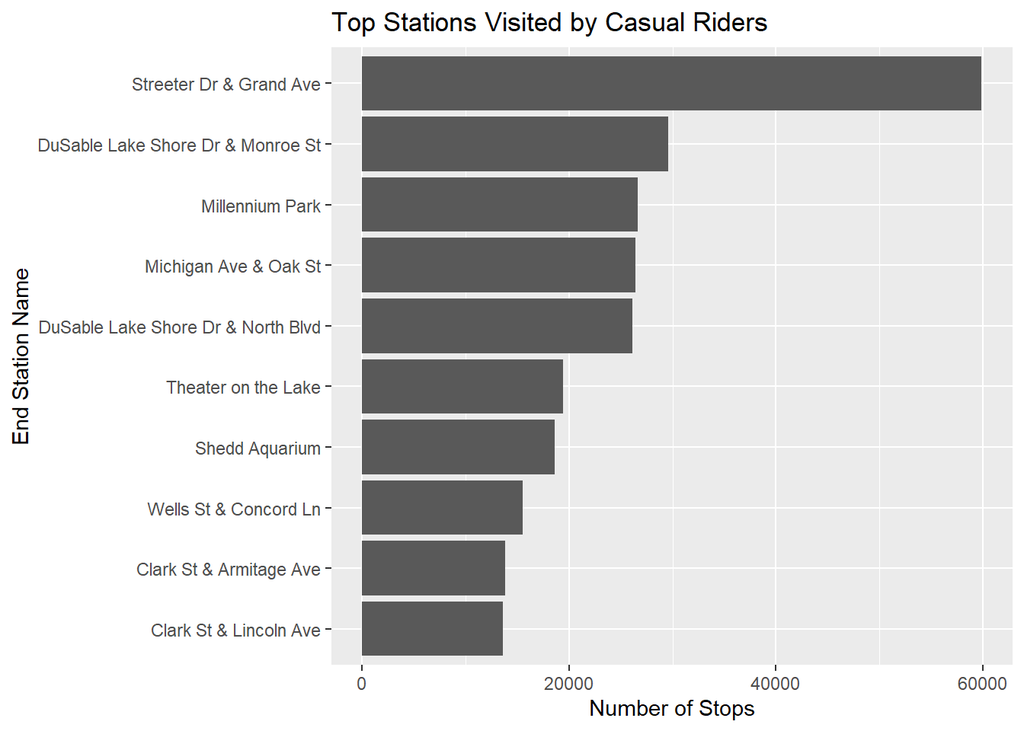

### Top three recommendations based on analysis

1. Digital marketing campaign showing the benefits of riding a Cyclistic bike to work or school, particularly targeting the most frequented stations
2. Black Friday sale on annual membership to attempt to convert casual riders
3. Explore profitability of a weekly pass and student pass offering

### Description of data sources used

The data source is provided by Motivate International Inc. and found at this [link](https://divvy-tripdata.s3.amazonaws.com/index.html). One specific limitation is that this is public data, therefore due to data privacy issues, we cannot link credit card information to purchases to explore if individuals are purchasing multiple day passes or if casual riders live in the Cyclistic service area.

### Documentation of any cleaning or manipulation of data

Once the data was all in one place, I began cleaning. I created a field ride_length which calculated the duration of a given ride by subtracting the started_at value from the ended_at value. I also created a day_of_week field using the weekdays command, as part of the analysis included comparing characteristics between different days of the week. I also pulled the month value out of the started_at variable so I could review trends on a monthly basis as well.

Using unique() I verified that there were exactly two responses in member_casual, no nulls and no mislabeled data.

I removed any ride_lengths with negative values. I also removed data where all of end_station_name, end_station_id, end_lat, and end_lang were missing. These bikes were removed from circulation by Cyclistic for QA or maintenance. These datapoints were extreme outliers in ride_length and would have affected the overall analysis.